# Statistical Inference - CLT Simulation Project

Tom Polak

December 12, 2017

## Overview

This project will investigate the exponential distribution in R and compare it with the Central Limit Theorem. For this analysis, a rate parameter of 0.2 will be set for all simulations. The analysis will then compare the distribution of averages of 40 exponentials over 1000 simulations.

## Simulations

Set the lambda, exponentials, and number of simulations (n)

```r
lambda = 0.2
exponentials = 40
n = 1000
```

Run the simulation with the set variables

```r
simMeans = NULL
for(i in 1:n) simMeans = c(simMeans, mean(rexp(exponentials,lambda)))
```

## Sample Mean vs Theoretical Mean

### Theoretical Mean

We know the theoretical mean is 1/lambda

```r
1/lambda
```

```
## [1] 5
```

### Sample Mean

Calculating the sample mean from the simulations we ran earlier

```r
mean(simMeans)
```

```
## [1] 4.988083
```

### Comparison

```r
abs(mean(simMeans) - 1/lambda)
```

```
## [1] 0.01191664
```

There is only a slight difference between the theoretical mean and the sample mean created from the 1000 simulations of 40 exponentials. Next we’ll take a look at the variance.

## Sample Variance vs Theoretical Variance

### Theoretical Variance

```r
(1/(lambda*sqrt(exponentials)))^2
```

```
## [1] 0.625
```

### Sample Variance

Calculating the sample variance from the simulations we ran earlier

```r
var(simMeans)
```

```
## [1] 0.627807
```

### Comparison

```r
abs(var(simMeans)-(1/(lambda*sqrt(exponentials)))^2)
```

```
## [1] 0.002807037
```

There is only a slight difference between the theoretical variance and the sample variance.

## Distribution

Below is a density histogram plot of the 1000 simulations. The normal distribution (black curve) is overlaid on the simulation data (blue histograms).

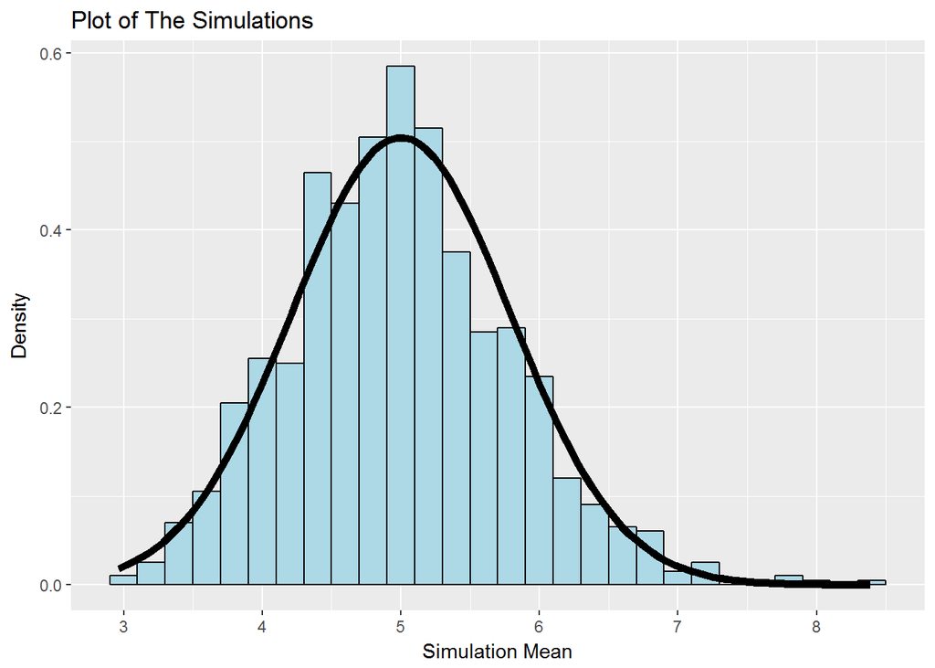

```r
ggplot(data.frame(simMeans), aes(x=simMeans)) +
  geom_histogram(aes(y=..density..), binwidth = 0.2, color = "black", fill = "light blue") +
  stat_function(fun=dnorm, args = list(mean = lambda^-1, sd=(lambda*sqrt(exponentials))^-1),size=2) +
  labs(
      title = "Plot of The Simulations",
      x = "Simulation Mean",
      y = "Density"
  )
```